# Forecasting Solar Radiation

Rushil Sirur

# 1 Objective

# 2 Libraries

```r
# Load libraries
library(TSA,quietly = TRUE)
library(fpp2,quietly = TRUE)
library(tidyverse,quietly = TRUE)
```

# 3 Data Preparation

## 3.1 Reading in Data

```r
# Reading in Data
solar <- read.csv("data1.csv",header = TRUE)
head(solar)
```

|  | solar | ppt |
| --- | --- | --- |
| 1 | 5.051729 | 1.333 |
| 2 | 6.415832 | 0.921 |
| 3 | 10.847920 | 0.947 |
| 4 | 16.930264 | 0.615 |
| 5 | 24.030797 | 0.544 |
| 6 | 26.298202 | 0.703 |

```r
# Subsetting Variable of Interest
solar <- solar$solar
# Structure of Dataset
str(solar)
```

```
 num [1:660] 5.05 6.42 10.85 16.93 24.03 ...
```

## 3.2 Missing Values

Check for missing values in the series.

```r
# Missing Values
is.na(solar) %>% summary()
```

```
   Mode   FALSE
logical     660
```

There are no missing values in the series.

## 3.3 Create Train and Test Split

Create a train and test split with approximately 80% train and rest test. But this value will be adjusted so that the first observation of the test series is January. Because the data is seasonal (monthly) we try to find the row number which gives a remainder of 1 when divided by 12 (nearest to the 80% of the data).

```r
# Observation No to Split
length(solar) * 0.80
```

```
[1] 528
```

```r
# Modulus of 528
528 %% 12
```

```
[1] 0
```

```r
# Modulus of 529
529 %% 12 # 1. The test set starts at the 529th observation of solar series.
```

```
[1] 1
```

The test set should start at the 529th observation and the train set should end at the 528th observation.

```r
# Create Train Set
solarTrain <- window(x = solar,end = 528)
# Create Test Set
solarTest <- window(x = solar,start = 529)
```

## 3.4 Create TS Object

The data is monthly, so the frequency of the series is 12. Convert both the train and test sets to a time series object with frequency of 12.

```r
# Train Series Conversion to TS
solarTrain <- ts(data = solarTrain,start = c(1960,1),frequency = 12)
head(solarTrain)
```

```
           Jan       Feb       Mar       Apr       May       Jun
1960  5.051729  6.415832 10.847920 16.930264 24.030797 26.298202
```

```r
str(solarTrain)
```

```
 Time-Series [1:528] from 1960 to 2004: 5.05 6.42 10.85 16.93 24.03 ...
```

```r
# Test Series Conversion to TS
solarTest <- ts(data = solarTest,start = c(2004,1),frequency = 12)
head(solarTest)
```

```
           Jan       Feb       Mar       Apr       May       Jun
2004  5.281160  6.479864 11.939498 15.568476 18.544593 19.822544
```

```r
str(solarTest)
```

```
 Time-Series [1:132] from 2004 to 2015: 5.28 6.48 11.94 15.57 18.54 ...
```

# 4 Data Exploration

The data exploration step involves trying to understand the characteristics of the series.

## 4.1 Time Series Plot

The time series plot of training set is below.

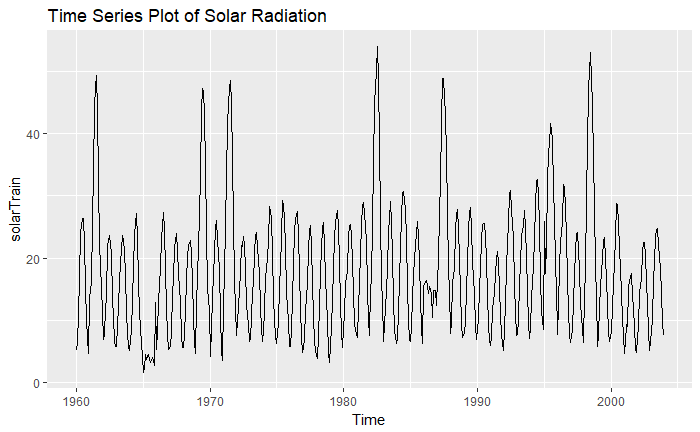

```r
# Time Series Plot
autoplot(solarTrain) +
    ggtitle("Time Series Plot of Solar Radiation")
```

The time series plot shows the following characteristics:

1. Seasonal Pattern: A clear seasonal pattern is seen in the plot.
2. Trend: There is no visible trend in the data.
3. The seasonal patterns vary across the series.

## 4.2 ACF Plot

Plot the ACF Plot for the training set and check for any characteristics.

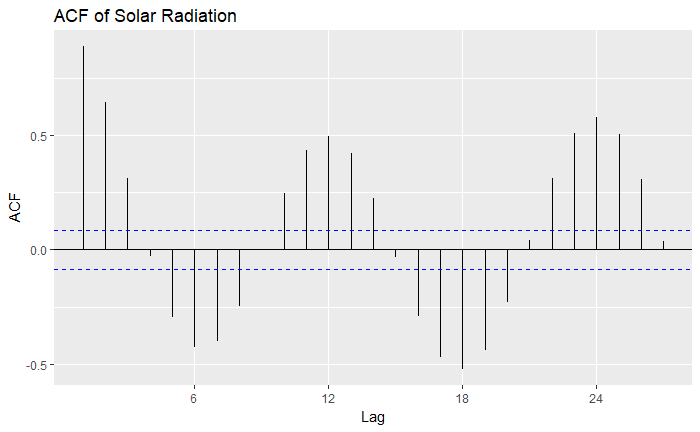

```r
# ACF of Train Set
ggAcf(solarTrain) + ggtitle("ACF of Solar Radiation")
```

The ACF plot shows a seasonal pattern with frequency 12. Also, there is no sign of trend.

## 4.3 Seasonal Subseries Plot

Plot the seasonal subseries plot to check the seasonal pattern between seasons and within seasons.

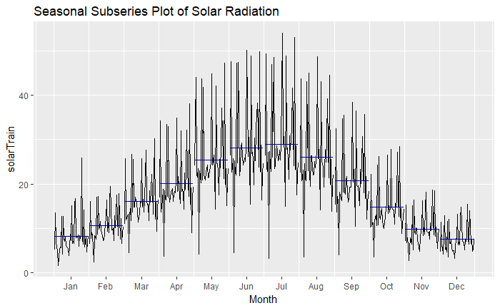

```r
# Seasonal Subseries Plot
ggsubseriesplot(x = solarTrain) + ggtitle("Seasonal Subseries Plot of Solar Radiation")
```

The mean radiation is lowest during the start and the end of the year and highest during mid year (June, July). Within each month there is a lot of variation in the solar radiation values.

## 4.4 ARMA Characteristics

We check the possible ARMA characteristics for the series.

```r
# Stationarity of Solar Radiation Data
# AdfTest
ar(diff(solarTrain)) # Selected 27 lags
```

```
Call:
ar(x = diff(solarTrain))

Coefficients:
      1        2        3        4        5        6        7        8
 0.1358   0.2634   0.0498  -0.0971  -0.2374  -0.1657  -0.0717  -0.1681
      9       10       11       12       13       14       15       16
-0.0366  -0.0076   0.0895  -0.0626  -0.0885  -0.0529  -0.1469  -0.0915
     17       18       19       20       21       22       23       24
-0.0119  -0.0175  -0.0283  -0.0719  -0.1159   0.0018   0.0157   0.1081
     25       26       27
 0.0131  -0.0557  -0.1258

Order selected 27  sigma^2 estimated as  6.082
```

```r
fUnitRoots::adfTest(solarTrain,lags = 27)# P Value 0.36, so accept null hypothesis of non stationarity
```

```
Title:
 Augmented Dickey-Fuller Test

Test Results:
  PARAMETER:
    Lag Order: 27
  STATISTIC:
    Dickey-Fuller: -0.7813
  P VALUE:
    0.3673

Description:
 Fri Nov 30 21:42:59 2018 by user: Rushil Sirur
```

```r
# Seasonal Difference Series
solarDiff <- diff(solarTrain,lag = 12)
# Adf of Differenced Series
ar(diff(solarDiff)) # Lags selected 24
```

```
Call:
ar(x = diff(solarDiff))

Coefficients:
      1        2        3        4        5        6        7        8
 0.0661   0.2038   0.1639   0.0176  -0.1825  -0.1399  -0.0780  -0.1004
      9       10       11       12       13       14       15       16
 0.0447  -0.0248   0.0730  -0.7913  -0.0379   0.0816   0.0902   0.0069
     17       18       19       20       21       22       23       24
-0.0850  -0.0824  -0.0731  -0.0719   0.0036  -0.0024   0.0775  -0.3488

Order selected 24  sigma^2 estimated as  7.003
```

```r
fUnitRoots::adfTest(x = solarDiff,lags = 24)#p value 0.01 Accept alternate hypothesis of stationarity
```

```
p-value smaller than printed p-value
```

```
Title:
 Augmented Dickey-Fuller Test

Test Results:
  PARAMETER:
    Lag Order: 24
  STATISTIC:
    Dickey-Fuller: -4.6155
  P VALUE:
    0.01

Description:
 Fri Nov 30 21:43:00 2018 by user: Rushil Sirur
```

```r
# EACF of Differenced Series
eacf(z = solarDiff)# indicates AR 2 and MA 2
```

```
AR/MA
  0 1 2 3 4 5 6 7 8 9 10 11 12 13
0 x x x x x x o x x x x  x  x  x
1 x x x x x x o x x x x  x  x  x
2 x x o x x o x x x x o  x  x  o
3 x x x x x o x o o o x  x  x  o
4 x x x x o o x o o o x  x  x  o
5 o o x o x x o o o o o  x  x  x
6 x o x o x x o o o o o  x  x  x
7 o o x x x x o o o o o  x  x  o
```

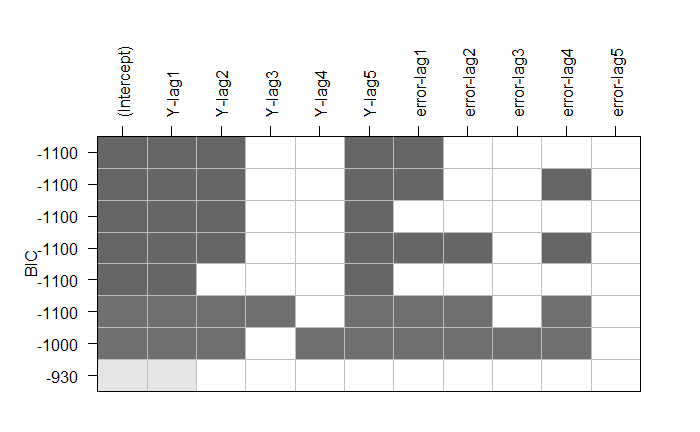

```r
# ARMA Subsets
plot(armasubsets(solarDiff,nar = 5,nma = 5))# AR 2 and MA 1
```

The possible SARIMA Models indicated are ARIMA(0,0,0)x(2,1,1 or 2). The idea here is not to find an ARIMA model, but the above indicates that ARIMA models can also be explored in addition to models incorporatin Trend and Seasonality.

# 5 Analysis

We consider models which deal with characteristics of trend and seasonality and also models that deal with Autocorrelation structure.

Initially we apply some basic forecasting methods before moving to advanced methods. We use the MASE values to compare the models.

## 5.1 Methodology

The following methodology is applied to all models.

1. Model Fitting

In this step we fit the different models to the training data.

2. Plot of Model Fit

The model is plotted by overlaying the fitted model on the Training series.

3. Accuracy on Training Data

The accuracy on Training data using MASE values in measured.

4. Residual Plots

We check the residual plots. Mainly we check the autocorrelation in the ACF of the residuals and time plot of residuals. In the autocorrelation we would like to see no autocorrelation and in the time plot we would ideally like to see no patterns and no changing variance of the residuals.

5. Residual Statistics

We check the mean of residuals and Shapiro Wilk test to check normality of residuals. The mean should be zero and normality is ideal.

In the residuals, the autocorrelation and mean of residuals are important as far the point forecasts are concerned. The normality and changing variance affect the prediction intervals of the point forecast.

6. Test Prediction

We get the forecast for the test series and then get the accuracy using MASE between the predictions and actual test series. If the residuals are not normal then we can use the bootstrap method to calculate prediction intervals.

7. Forecast Plot

The forecasts are plotted to how it compares with the series.

8. Observations

Summarize the model information and update the results in the results data frame.

The results of the models will be stored in a data frame.

Creating the data frame below:

```r
# Results Data Frame
modelResults <- data.frame(
    Model = character(),
    TrainAcc. = numeric(),
    TestAcc. = numeric(),
    Res.Autocorr = character(),
    Res.Variance = character(),
    Res.Timeplot = character(),
    Res.Mean = numeric(),
    Res.Normality = character(),
    stringsAsFactors = FALSE
)
# Setting Forecast Length
h <- length(solarTest)
```

# 6 Seasonal Naive Model

In the seasonal Naive method the forecast is set to the value observed in the same month of the last year.

## 6.1 Model Fitting

```r
# Seasonal Naive Method on Original Data
seasNaive <- snaive(y = solarTrain,h = h)
```

## 6.2 Plot of Model Fit

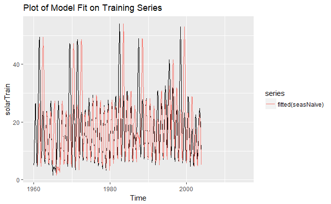

```r
# Plot of Model Fit on Train Data
autoplot(seasNaive,fcol = NA,PI = FALSE) +
    autolayer(object = fitted(seasNaive)) +
    ggtitle("Plot of Model Fit on Training Series")
```

## 6.3 Accuracy on Training Data

```r
# Accuracy on Training Set
accuracy(f = seasNaive)# MASE 1
```

```
                     ME     RMSE      MAE       MPE     MAPE MASE      ACF1
Training set 0.04539614 10.21634 6.997806 -16.34367 45.38632    1 0.9289044
```

## 6.4 Residual Plots

Analyse the residuals plots of the Model Fit.

```
    Ljung-Box test

data:  Residuals from Seasonal naive method
Q* = 2355, df = 24, p-value < 2.2e-16

Model df: 0.   Total lags used: 24
```

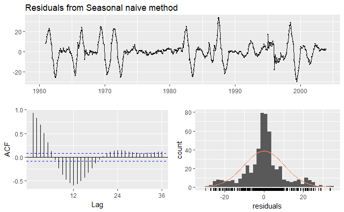

```r
# Residual Plots of Train Data
checkresiduals(seasNaive)
```

Autocorrelation: The ACF plot and Ljung Box test indicate presence of autocorrelation in the series.

Constant Variance: The variance of the residuals is also not constant as seen in the time plot of residuals. Also patterns in the time plot shows the fit is not good.

## 6.5 Residual Statistics

```r
# Mean of Residuals of Train Data
mean(resid(seasNaive),na.rm = TRUE)
```

```
[1] 0.04539614
```

```r
# Normality of Residuals of Train Data
shapiro.test(x = seasNaive$residuals)# Null: Normality
```

```
    Shapiro-Wilk normality test

data:  seasNaive$residuals
W = 0.95134, p-value = 5.321e-12
```

Mean of Residuals: The mean of residuals should ideally be close to 0. But here it is 0.045, so the fit is not very good.

Normality of Residuals: The Shapiro Wilk test indicates that the residuals are not normal.

## 6.6 Test Prediction

We apply the model on the test set and get accuracy measures.

```r
# Generate forecasts from model
seasNaiveFcast <- forecast(object = seasNaive,h = h,simulate = TRUE,bootstrap = TRUE)
# Compare Accuracy With Test Set for Predictions
seasNaiveTestAcc <- accuracy(f = seasNaiveFcast,x = solarTest)
seasNaiveTestAcc
```

```
                     ME     RMSE      MAE        MPE     MAPE      MASE
Training set 0.04539614 10.21634 6.997806 -16.343674 45.38632 1.0000000
Test set     0.23414855  3.68921 2.971007  -6.026305 19.50929 0.4245627
                  ACF1 Theil's U
Training set 0.9289044        NA
Test set     0.8688421 0.9053853
```

The MASE value for the training set is 1, while for the test set it is 0.424, which means it actually does better on the test set.

## 6.7 Forecast Plot

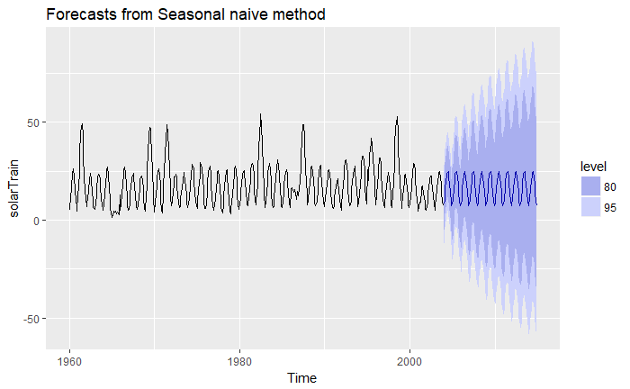

```r
autoplot(seasNaiveFcast)
```

## 6.8 Observations

The seasonal naive method gives a MASE of 0.424 on the test data but there are issues with the residuals with autocorrelation, non normality.

Adding the results to Results dataframe.

```r
# Update modelResults
#c("Model","TrainAcc.","TestAcc.","Res.Autocorr","Res.Variance","Res.Timeplot","Res.Mean","Res.Normality")#
# Train Data Results
seasNaiveResult <- data.frame("Seasonal Naive",1,0.424,"Present","Present","Pattern",0.045,"Non Normality",stringsAsFactors = FALSE)
names(seasNaiveResult) <- c("Model","TrainAcc.","TestAcc.","Res.Autocorr","Res.Variance","Res.Timeplot","Res.Mean","Res.Normality")
modelResults <- rbind(modelResults,seasNaiveResult)
rm(seasNaive,seasNaiveFcast,seasNaiveResult,seasNaiveTestAcc)
```

# 7 **Linear Seasonal Model**

This model fits a linear model to the data, with the predictor being the seasonal periods in the data.

## 7.1 Model Fitting

```r
# Linear Seasonal Model on Train Data
lin <- tslm(formula = solarTrain ~ season)
summary(lin)
```

```
Call:
tslm(formula = solarTrain ~ season)

Residuals:
     Min       1Q   Median       3Q      Max
-25.8073  -3.2949  -1.4320   0.8299  25.0511

Coefficients:
            Estimate Std. Error t value Pr(>|t|)
(Intercept)   8.1912     1.0347   7.916 1.51e-14 ***
season2       2.4678     1.4633   1.686   0.0923 .
season3       7.8695     1.4633   5.378 1.14e-07 ***
season4      11.8696     1.4633   8.111 3.68e-15 ***
season5      17.1312     1.4633  11.707  < 2e-16 ***
season6      19.9663     1.4633  13.644  < 2e-16 ***
season7      20.8141     1.4633  14.224  < 2e-16 ***
season8      17.8251     1.4633  12.181  < 2e-16 ***
season9      12.5335     1.4633   8.565  < 2e-16 ***
season10      6.6524     1.4633   4.546 6.82e-06 ***
season11      1.5940     1.4633   1.089   0.2765
season12     -0.6505     1.4633  -0.445   0.6568
---
Signif. codes:  0 *** 0.001 ** 0.01 * 0.05 . 0.1   1

Residual standard error: 6.864 on 516 degrees of freedom
Multiple R-squared:  0.557, Adjusted R-squared:  0.5475
F-statistic: 58.97 on 11 and 516 DF,  p-value: < 2.2e-16
```

The linear model on Train data is significant overall and has an adjusted R Square of 0.5475.

## 7.2 Plot of Model Fit

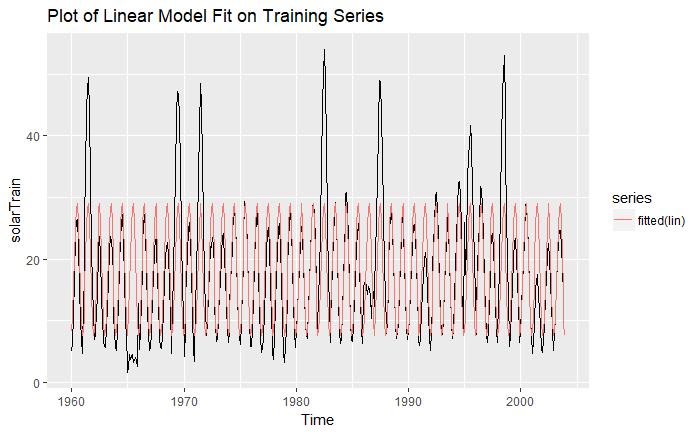

```r
# Plot of Model Fit on Train Data
autoplot(solarTrain,fcol = NA,PI = FALSE) +
    autolayer(object = fitted(lin)) +
    ggtitle("Plot of Linear Model Fit on Training Series")
```

## 7.3 Accuracy on Training Data

```r
# Accuracy on Training Set
accuracy(f = lin)# MASE 0.5615
```

```
                       ME     RMSE      MAE       MPE     MAPE      MASE
Training set 1.858797e-16 6.785157 4.499788 -17.36976 33.09337 0.5615581
```

The training accuracy of the linear model is MASE 0.561

## 7.4 Residual Plots

Analyse the residuals plots of the Model Fit.

```
    Breusch-Godfrey test for serial correlation of order up to 24

data:  Residuals from Linear regression model
LM test = 476.17, df = 24, p-value < 2.2e-16
```

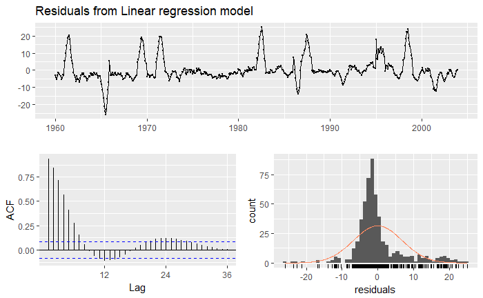

```r
# Residual Plots of Train Data
checkresiduals(lin)
```

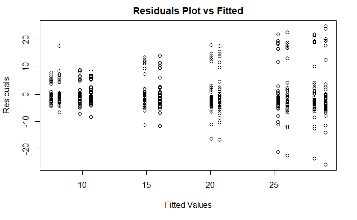

```r
# Fitted vs Residuals
plot(x = lin$fitted.values,y = lin$residuals ,xlab = "Fitted Values",ylab = "Residuals",main = "Residuals Plot vs Fitted")
```

Autocorrelation: There is still autocorrelations in the residuals of the model.

Constant Variance: There is changing variance in the residuals. Also the fit of the model is not good since there are patterns in the data.

The fitted values against the predictor also shows a changing variance which indicates the fit could be improved.

## 7.5 Residual Statistics

```r
# Mean of Residuals of Train Data
mean(resid(lin),na.rm = TRUE)
```

```
[1] 2.414421e-16
```

```r
# Normality of Residuals of Train Data
shapiro.test(x = lin$residuals)# Null: Normality
```

```
    Shapiro-Wilk normality test

data:  lin$residuals
W = 0.84562, p-value < 2.2e-16
```

The model has almost zero mean for residuals and non normal residuals.

## 7.6 Test Prediction

We apply the model on the test set and get accuracy measures.

```r
# Generate forecasts for Train Data
linFcast <- forecast(object = lin,h = h,simulate = TRUE,bootstrap = TRUE)
# Compare Accuracy With Test Set
linTestAcc <- accuracy(f = linFcast,x = solarTest)
linTestAcc
```

```
                        ME     RMSE      MAE       MPE     MAPE      MASE
Training set  1.858797e-16 6.785157 4.499788 -17.36976 33.09337 0.6430284
Test set     -1.213427e+00 3.667776 2.592286 -12.49986 19.10203 0.3704427
                  ACF1 Theil's U
Training set 0.9340587        NA
Test set     0.8971213 0.9805108
```

The linear model gives a MASE of 0.3704 on the test set.

## 7.7 Forecast Plot

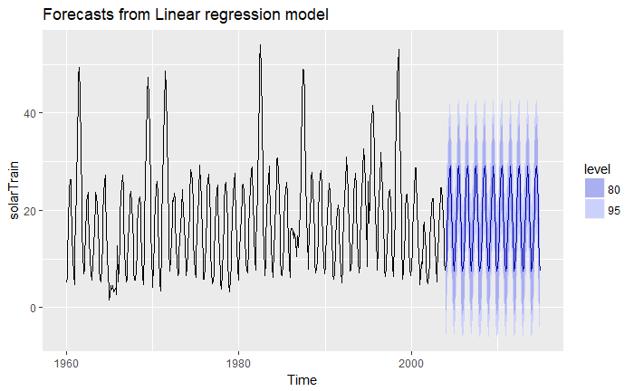

```r
autoplot(object = linFcast)
```

## 7.8 Observations

The linear model gives a better result than the Seasonal Naive model on the test set with a MASE of 0.370, but the residuals again have correlation which indicates that the model fitting is not very good.

Adding the results to Results dataframe.

```r
# Update modelResults
#c("Model","TrainAcc.","TestAcc.","Res.Autocorr","Res.Variance","Res.Timeplot","Res.Mean","Res.Normality")#
# Train Data Results
linResult <- data.frame("Linear Model",0.5615,0.370,"Present","Present","Pattern",2.414*10^-16,"Non Normality",stringsAsFactors = FALSE)
names(linResult) <- c("Model","TrainAcc.","TestAcc.","Res.Autocorr","Res.Variance","Res.Timeplot","Res.Mean","Res.Normality")
modelResults <- rbind(modelResults,linResult)
rm(lin,linFcast,linResult,linTestAcc)
```

# 8 **STL Decomposition**

This models is the Seasonal and Trend Decomposition using loess method. It is primarily a decomposition method but can be used to produce forecasts.

## 8.1 Model Fitting

```r
# STL Model on Train Data
stl <- stlf(y = solarTrain,h = h,s.window = 15,method = "ets",etsmodel = "ZNN")
```

The STLF function applies the STF method. The seasonal component is estimated and then the seasonally adjusted data is estimated using a trend model. Then the trend and seasonal values are combined to give forecasts.

## 8.2 Plot of Model Fit

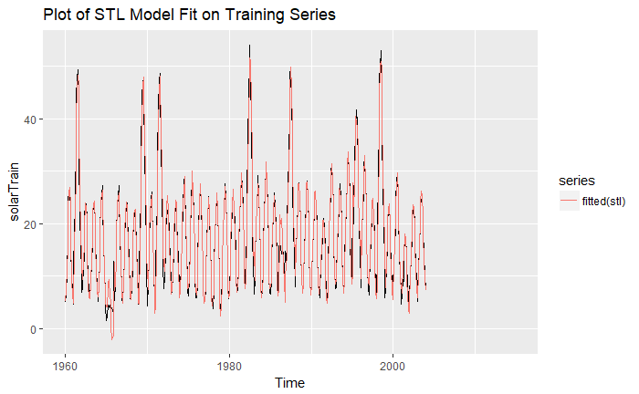

```r
# Plot of Model Fit on Train Data
autoplot(stl,fcol = NA,PI = FALSE) +
    autolayer(object = fitted(stl)) +
    ggtitle("Plot of STL Model Fit on Training Series")
```

## 8.3 Accuracy on Training Data

```r
# Accuracy on Training Set for Train Data
accuracy(f = stl)# MASE 0.217
```

```
                      ME    RMSE      MAE       MPE     MAPE      MASE
Training set 0.006162009 2.38838 1.520788 -1.484613 12.75084 0.2173236
                  ACF1
Training set 0.2005732
```

## 8.4 Residual Plots

Analyse the residuals plots of the Model Fit.

```
    Ljung-Box test

data:  Residuals from STL +  ETS(A,N,N)
Q* = 237.27, df = 22, p-value < 2.2e-16

Model df: 2.   Total lags used: 24
```

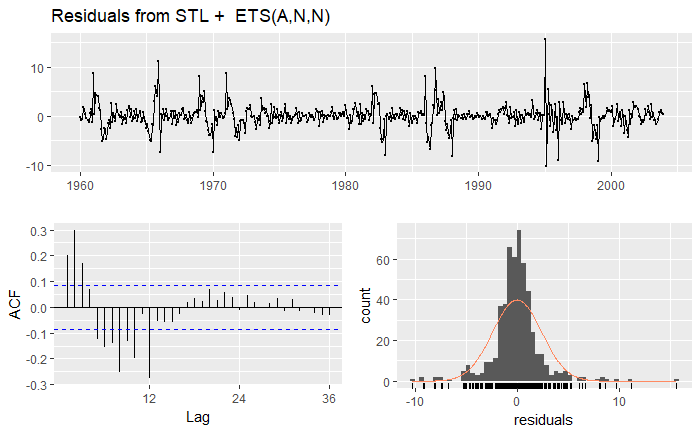

```r
# Residual Plots of Train Data
checkresiduals(stl)
```

Autocorrelation: There is still autocorrelations in the residuals of the model.

Constant Variance: There is changing variance in the residuals. Also the fit of the model is not good since there are patterns in the data.

But this model seems better than the previous models in terms of residuals even though this is also not error free.

## 8.5 Residual Statistics

```r
# Mean of Residuals of Train Data
mean(resid(stl),na.rm = TRUE)
```

```
[1] 0.006162009
```

```r
# Normality of Residuals of Train Data
shapiro.test(x = stl$residuals)# Null: Normality
```

```
    Shapiro-Wilk normality test

data:  stl$residuals
W = 0.88287, p-value < 2.2e-16
```

The model has almost zero mean for residuals and non normal residuals.

## 8.6 Test Prediction

We apply the model on the test set and get accuracy measures.

```r
# Generate forecasts for Train Data
stlFcast <- forecast(object = stl,h = h,simulate = TRUE,bootstrap = TRUE)
# Compare Accuracy With Test Set
stlTestAcc <- accuracy(f = stlFcast,x = solarTest)
stlTestAcc
```

```
                       ME     RMSE      MAE        MPE     MAPE      MASE
Training set  0.006162009 2.388380 1.520788  -1.484613 12.75084 0.2173236
Test set     -0.944449702 3.590508 2.663839 -11.493091 19.35647 0.3806677
                  ACF1 Theil's U
Training set 0.2005732        NA
Test set     0.8885955 0.9520292
```

The STL model gives a MASE of 0.380 on the test set.

## 8.7 Forecast Plot

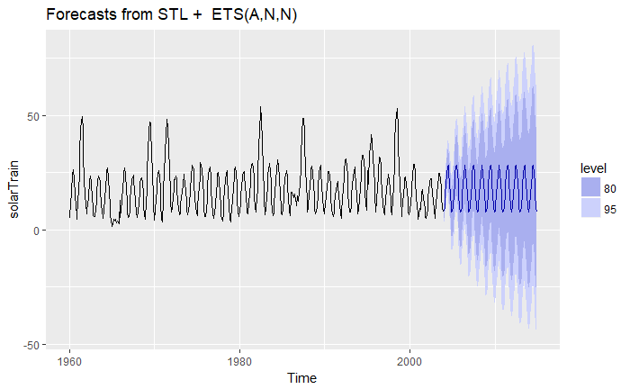

```r
autoplot(object = stlFcast)
```

## 8.8 Observations

The STL Model has almost equivalent performance on the test set as compared to the Linear Model, but gives better residuals although the residuals of this model also have autocorrelation and changing variance and non normality.

Adding the results to Results dataframe.

```r
# Update modelResults
#c("Model","TrainAcc.","TestAcc.","Res.Autocorr","Res.Variance","Res.Timeplot","Res.Mean","Res.Normality")#
# Train Data Results
stlResult <- data.frame("STL Model",0.217,0.380,"Present","Present","Pattern",0.00616,"Non Normality",stringsAsFactors = FALSE)
names(stlResult) <- c("Model","TrainAcc.","TestAcc.","Res.Autocorr","Res.Variance","Res.Timeplot","Res.Mean","Res.Normality")
modelResults <- rbind(modelResults,stlResult)
rm(stl,stlFcast,stlResult,stlTestAcc)
```